# CS166 Assignment 3

## Clustering

An interesting aspect of the modified model that it is very robust to parameter changes. While there might be a single node or so to be apart, the network rarely splits into multiple clusters.

```python
#function to test multiple parameters
def cluster(beta,gamma,n):
    sim=SocialDynamicsSimulation(beta=beta,gamma=gamma)
    sim.initialize()
    for i in range(n):
        for i in range(1000):
            sim.update()
    plt.figure()
    sim.observe(0)
```

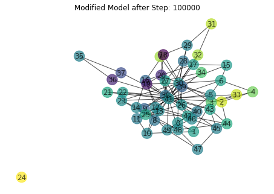

```python
cluster(0.3,4,100) #beta=0.3 gamma=4
```

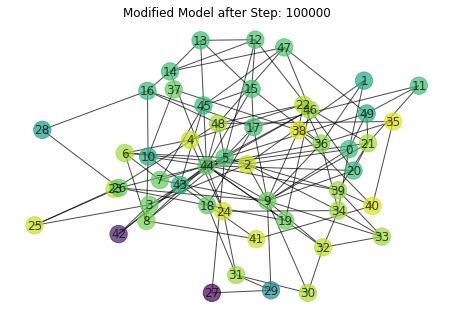

```python
cluster(0.3,2,100) #beta=0.3 gamma=2
```

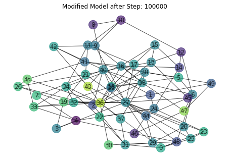

```python
cluster(0.3,1,100) #beta=0.3 gamma=1
```

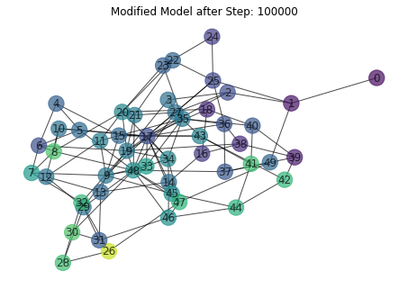

```python
cluster(0.2,3,100) #beta=0.2 gamma=3
```

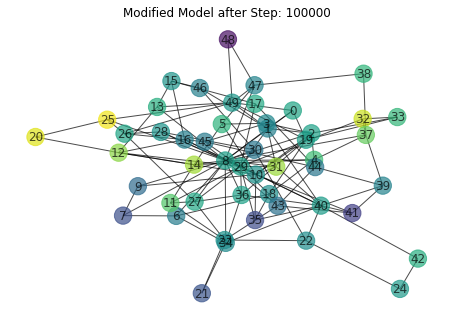

```python
cluster(0.1,3,100) #beta=0.1 gamma=3
```

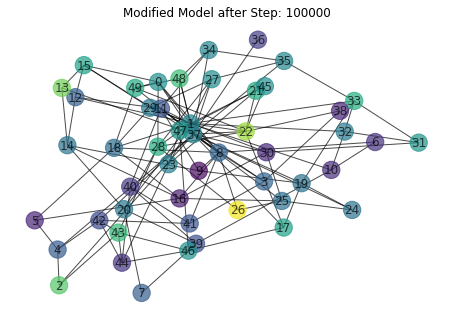

```python
cluster(1,3,100) #beta=1 gamma=3
```

The two parameters of our model are bound by:

1. $0<\beta<1$ as it is a scalar multiplier of weight, which must be in-between $0$ and $1$.
2. $0<\gamma$ unless we do not want to incorporate opinion difference into our weight update algorithm.
3. $\gamma\leq1+\frac{1}{\beta}$ so that weight cannot get greater than $1$ and less than $0$.

This is the behaviour I intened, as I believed that for a realistic social network of 50 peoples is well within the theoretical Dunbar number of managable social circles.

# Appendix

## HC Applications

**#systemdynamics**: Through my vector plots I describe the behaviour of our network by referencing bases of attractions and describing the parameter values which specify the locus of attractors. Consequently, I explain what might be the cause of these behaviours and how they relate to real-life social networks.

**#constraints**: In my Local Analysis and Simulation sections I identify the constraints for the parameters of our model, and consequently analyse the model's behaviour within these constraints. Following that I link the model's behaviour to my modifications and how it achieves a realistic simulation.

```python
#modified model
class SocialDynamicsSimulation:
    def __init__(self, network_size=50, beta=0.3, gamma=4):

        self.network_size = network_size
        self.beta = beta
        self.gamma = gamma

    def initialize(self):
        '''
        Initialize the simulation with a random graph, with random 0 or 1
        opinions assigned to all nodes and initial edge weights of 0.5.
        '''
        self.graph = nx.watts_strogatz_graph(50, 5, 0.5)
        for edge in self.graph.edges:
            self.graph.edges[edge]['weight'] = 0.5
        for node in self.graph.nodes:
            self.graph.nodes[node]['opinion'] = [random.randint(0, 1) for _ in range(10)] #10 opinions
            self.graph.nodes[node]['alpha'] =float(sts.expon.rvs(loc=0,scale=1/100,size=1)) #alpha dist by expon function
        self.layout = nx.spring_layout(self.graph)  # Initial visual layout
        self.step = 0

    def observe(self,oi):
        '''
        Draw the state of the network
        '''
        self.layout = nx.spring_layout(self.graph, pos = self.layout, iterations=5)
        plt.clf()
        nx.draw(
            self.graph, pos=self.layout, with_labels=True,
            node_color=[self.graph.nodes[i]['opinion'][oi] for i in self.graph.nodes],
            edge_color=[self.graph.edges[i, j]['weight'] for i, j in self.graph.edges],
            edge_cmap=plt.cm.binary, edge_vmin=0, edge_vmax=1,
            alpha=0.7, vmin=0, vmax=1)
        plt.title('Modified Model after Step: ' + str(self.step))

    def update(self):
        if  np.random.normal(nx.density(self.graph),0.01) < 0.07 and random.uniform(0,1)<0.05:
            while True:
                #find node degrees
                nodes = list(self.graph.nodes)
                degrees=[self.graph.degree[n] for n in nodes]
                degrees_weighted=[random.uniform(0,1)*i for i in degrees] #a random probability table weighted by degree
                new_edge=(degrees_weighted.index(max(degrees_weighted)),
                          random.choice(nodes))
                if new_edge not in self.graph.edges and new_edge[0]!=new_edge[1]:
                    break
            weight=np.random.normal(0.5,0.1)%1 #weight normally distributed around 0.5
            self.graph.add_edge(new_edge[0], new_edge[1], weight=weight)
        else:
            # Select a random edge and a random opinion update node opinions and edge weight
            edge = random.choice(list(self.graph.edges))
            weight = self.graph.edges[edge]['weight']
            opinion_index=random.randint(0,9)
            opinions = [self.graph.nodes[n]['opinion'][opinion_index] for n in edge]
            opinions_weight= [self.graph.nodes[n]['opinion'] for n in edge]
            alphas= [self.graph.nodes[n]['alpha'] for n in edge]
            for i in [0, 1]:
                self.graph.nodes[edge[i]]['opinion'][opinion_index] = (
                    opinions[i] + alphas[i] * weight * (opinions[1-i] - opinions[i]))
            self.graph.edges[edge]['weight'] = (
                weight +
                self.beta * weight * (1-weight) *
                (1 - self.gamma * abs(np.mean(opinions_weight[0]) - np.mean(opinions_weight[1]))))
            # Remove very weak connections
            if self.graph.edges[edge]['weight'] < 0.05:
                self.graph.remove_edge(*edge)
        self.step += 1
```

```python
#unmodified model
class SocialDynamicsSimulation_UM:
    '''
    Simulate social dynamics by strengthening opinions and connection weights
    based on random interactions between nodes.
    '''

    def __init__(self, network_size=50, alpha=0.03, beta=0.3, gamma=4):
        '''
        Inputs:

            network_size (int) The number of nodes in the random Watts-Strogatz
              small-world network. Default: 50.

            alpha (float) The rate at which nodes adjust their opinions to
              match neighboring nodes' opinions during interactions.
              Default: 0.03.

            beta (float) The rate at which edge weights are changed in
              response to differing opinions. Default: 0.3.

            gamma (float) The pickiness of nodes. Nodes with opinions differing
              by more than 1/gamma will result in an edge weight decreasing.
              Default: 4.
        '''
        self.network_size = network_size
        self.alpha = alpha
        self.beta = beta
        self.gamma = gamma

    def initialize(self):
        '''
        Initialize the simulation with a random graph, with random 0 or 1
        opinions assigned to all nodes and initial edge weights of 0.5.
        '''
        self.graph = nx.watts_strogatz_graph(50, 5, 0.5)
        for edge in self.graph.edges:
            self.graph.edges[edge]['weight'] = 0.5
        for node in self.graph.nodes:
            self.graph.nodes[node]['opinion'] = random.randint(0, 1)
        self.layout = nx.spring_layout(self.graph)  # Initial visual layout
        self.step = 0

    def observe(self):
        '''
        Draw the state of the network.
        '''
        self.layout = nx.spring_layout(self.graph, pos = self.layout, iterations=5)
        plt.clf()
        nx.draw(
            self.graph, pos=self.layout, with_labels=True,
            node_color=[self.graph.nodes[i]['opinion'] for i in self.graph.nodes],
            edge_color=[self.graph.edges[i, j]['weight'] for i, j in self.graph.edges],
            edge_cmap=plt.cm.binary, edge_vmin=0, edge_vmax=1,
            alpha=0.7, vmin=0, vmax=1)
        plt.title('Original Model after Step: ' + str(self.step))

    def update(self):
        if random.uniform(0, 1) < 0.01:
            # Create a new edge with weight 0.5 between two unconnected nodes
            nodes = list(self.graph.nodes)
            while True:
                new_edge = random.sample(nodes, 2)
                if new_edge not in self.graph.edges:
                    break
            self.graph.add_edge(new_edge[0], new_edge[1], weight=0.5)
        else:
            # Select a random edge and update node opinions and edge weight
            edge = random.choice(list(self.graph.edges))
            weight = self.graph.edges[edge]['weight']
            opinions = [self.graph.nodes[n]['opinion'] for n in edge]
            for i in [0, 1]:
                self.graph.nodes[edge[i]]['opinion'] = (
                    opinions[i] + self.alpha * weight * (opinions[1-i] - opinions[i]))
            self.graph.edges[edge]['weight'] = (
                weight +
                self.beta * weight * (1-weight) *
                (1 - self.gamma * abs(opinions[0] - opinions[1])))
            # Remove very weak connections
            if self.graph.edges[edge]['weight'] < 0.05:
                self.graph.remove_edge(*edge)
        self.step += 1
```

```python
#trace plot from session 7.2
def w_o_plot():
    cmap = cm.cividis
    plt.figure(figsize=(16,8))
    for opinion, weight in [
        [0.25, 0.95], [0.45, 0.95], [0.55, 0.95], [0.65, 0.95], [0.75, 0.95],
        [0.85, 0.95], [0.95, 0.95], [0.35, 0.65], [0.45, 0.75], [0.95, 0.75],
        [0.95, 0.35], [0.3, 0.25], [0.3, 0.15], [0.15, 0.06], [0.05, 0.06]
    ]:
        ow = [[opinion, 0.0, weight]]
        for i in range(100):
            delta_o = alpha * ow[-1][2] * (ow[-1][1] - ow[-1][0])
            delta_w = (
                beta * ow[-1][2] * (1-ow[-1][2]) *
                (1-gamma*abs(ow[-1][1] - ow[-1][0])))
            new_weight = ow[-1][2] + delta_w
            if new_weight < 0.05:
                new_weight = 0
            ow.append([ow[-1][0] + delta_o, ow[-1][1] - delta_o, new_weight])
        plt.plot(
            [row[0] - row[1] for row in ow],
            [row[2] for row in ow],
            color=(cmap(0.15) if ow[-1][2] == 0 else cmap(0.75)),
            alpha=0.75)

    # Plot vector field
    opinion = scipy.linspace(0, 1, 11)  # the difference in opinion, |o_i - o_j|
    weight = scipy.linspace(0, 1, 11)   # the edge weight, w_ij
    ow_grid = scipy.meshgrid(opinion, weight)
    delta_o_grid = -2*alpha * ow_grid[1] * ow_grid[0]
    delta_w_grid = beta * ow_grid[1] * (1-ow_grid[1]) * (1 - gamma * ow_grid[0])
    plt.quiver(ow_grid[0], ow_grid[1], delta_o_grid, delta_w_grid,scale=5, color='black',alpha=0.5)

    # Annotate plot
    plt.xlabel('opinion difference')
    plt.ylabel('weight')
    plt.plot([0, 1], [0.05, 0.05], 'k--')
    plt.show()
```